# R markdown final project testing

```r
process_test_session <- function(data, pca_model, preProc, fixed_pcs = 92, window_width = 0.1) {

  # Identify unique brain areas
  unique_brain_areas <- unique(data$brain_area)

  # Filter neurons belonging to those brain areas
  valid_neurons <- which(data$brain_area %in% unique_brain_areas)
  if (length(valid_neurons) == 0) return(NULL)  # Skip if no valid neurons

  # Extract relevant spike data
  filtered_spikes <- lapply(data$spks, function(trial) trial[valid_neurons, ])

  # Function to compute firing rates over time bins
  compute_firing_rates_time_resolved <- function(spike_matrix, time_vector, window_width) {
    start_time <- min(time_vector)
    end_time <- max(time_vector)
    bins <- seq(start_time, end_time, by = window_width)
    if (tail(bins, 1) < end_time) bins <- c(bins, end_time)

    firing_rates_windows <- sapply(1:(length(bins) - 1), function(i) {
      indices <- which(time_vector >= bins[i] & time_vector < bins[i+1])
      if (length(indices) == 0) return(rep(0, nrow(spike_matrix)))
      return(rowSums(spike_matrix[, indices, drop = FALSE]) / (bins[i+1] - bins[i]))
    })

    return(firing_rates_windows)
  }

  # Apply firing rate computation
  time_resolved_rates <- lapply(1:length(filtered_spikes), function(i) {
    compute_firing_rates_time_resolved(filtered_spikes[[i]], data$time[[i]], window_width)
  })

  # Flatten into single feature vectors
  flattened_rates <- lapply(time_resolved_rates, function(mat) as.vector(mat))

  # Create a data frame for trials
  trial_df <- do.call(rbind, flattened_rates)
  trial_df <- as.data.frame(trial_df)

  # Assign column names
  num_neurons <- length(valid_neurons)
  num_windows <- ncol(time_resolved_rates[[1]])
  colnames(trial_df) <- paste0("N", rep(1:num_neurons, each = num_windows),
                               "_W", rep(1:num_windows, times = num_neurons))

  # Remove constant columns
  remove_constant_columns <- function(df) {
    non_constant_cols <- sapply(df, function(col) length(unique(col)) > 1)
    return(df[, non_constant_cols])
  }
  trial_df <- remove_constant_columns(trial_df)

  # Ensure test data has the same column names as the PCA training data
  pca_train_data <- read.csv("pca_merged_data.csv")[, -1]  # Load PCA training data (excluding outcome column)
  required_columns <- colnames(pca_train_data)  # Get required feature names

  # Add missing columns with NA values
  for (col in required_columns) {
    if (!(col %in% colnames(trial_df))) {
      trial_df[[col]] <- 0  # Fill missing columns with 0s (or NA if preferred)
    }
  }

  # Keep only columns that exist in the PCA model
  trial_df <- trial_df[, required_columns]

  # Apply PCA transformation (using pre-trained PCA model)
  pca_transformed <- predict(pca_model, newdata = trial_df)

  # Extract the first 92 PCs
  num_available_pcs <- ncol(pca_transformed$x)
  num_pcs_to_keep <- min(fixed_pcs, num_available_pcs)
  selected_pcs <- as.data.frame(pca_transformed$x[, 1:num_pcs_to_keep])

  # Pad with NA columns if fewer than 92 PCs exist
  if (num_pcs_to_keep < fixed_pcs) {
    padding <- as.data.frame(matrix(NA, nrow = nrow(selected_pcs), ncol = fixed_pcs - num_pcs_to_keep))
    colnames(padding) <- paste0("PC", (num_pcs_to_keep + 1):fixed_pcs)
    selected_pcs <- cbind(selected_pcs, padding)
  }

  # Rename PC columns
  colnames(selected_pcs) <- paste0("PC", 1:fixed_pcs)

  # Apply standardization
  standardized_test_data <- predict(preProc, selected_pcs)

  return(standardized_test_data)
}

# Load PCA Model and Preprocessing Object
pca_model <- prcomp(read.csv("pca_merged_data.csv")[, -1], scale. = TRUE)
preProc <- preProcess(read.csv("pca_merged_data.csv")[, -1], method = c("center", "scale"))

# Process the test data
X_test_new <- process_test_session(test_data_new, pca_model, preProc)
```

```
## Error in pca_transformed$x: $ operator is invalid for atomic vectors
```

```r
# Extract only the spike data and convert to a structured format
spike_data <- lapply(test_data_new$spks, function(trial) as.vector(trial))  # Flatten each trial's matrix
test_features <- do.call(rbind, spike_data)  # Combine trials into a dataframe

# Convert to dataframe and check structure
test_data_processed <- as.data.frame(test_features)
dim(test_data_processed)  # Should match training PCA input dimensions
```

```
## [1]   100 29360
```

```r
# 1. Get the column names from the training data used in PCA
expected_columns <- colnames(X_train)  # Make sure this comes from training!

# Get column names in training data
train_columns <- colnames(X_train)

# Get column names in test data
test_columns <- colnames(test_data_processed)

# Find missing columns
missing_cols <- setdiff(train_columns, test_columns)
extra_cols <- setdiff(test_columns, train_columns)

# Print the differences
print("Columns missing in test data:")
```

```
## [1] "Columns missing in test data:"
```

```r
print("Columns in test data but not in training:")
```

```
## [1] "Columns in test data but not in training:"
```

```r
# Rename the first 92 columns in the test dataset to match the training dataset
colnames(test_data_processed)[1:92] <- colnames(X_train)

# Reorder columns to match training data
test_data_processed <- test_data_processed[, colnames(X_train), drop = FALSE]

# Verify dimensions (should match training)
print(dim(test_data_processed))
```

```
## [1] 100  92
```

```r
print(dim(X_train))  # Should be the same (except row count)
```

```
## [1] 4066   92
```

```r
# 2. Match columns in test data to training columns
test_data_processed <- test_data_processed[, expected_columns, drop = FALSE]

# 3. Standardize using the same pre-processing from training
test_features_scaled <- predict(preProc, test_data_processed)

# 4. Apply PCA transformation
pca_transformed <- predict(pca_model, newdata = test_features_scaled)

# 5. Extract first 92 PCs (Ensure it matches training PCA output)
X_test_new <- as.data.frame(pca_transformed[, 1:92])

# 6. Check if dimensions match expected PCA output (should be 100 x 92)
dim(X_test_new)
```

```
## [1] 100  92
```

```r
# Predict feedback type on the new test data
rf_predictions <- predict(rf_model, newdata = X_test_new)

# Convert actual test labels to factor
y_test_new <- as.factor(test_data_new$feedback_type)

# Ensure factor levels match between predictions and actual values
rf_predictions <- factor(rf_predictions, levels = levels(y_test_new))

# Compute Confusion Matrix
conf_matrix_rf <- confusionMatrix(rf_predictions, y_test_new)

# Print confusion matrix results
print(conf_matrix_rf)
```

```
## Confusion Matrix and Statistics
##
##           Reference
## Prediction -1  1
##         -1  0  0
##         1  28 72
##
##                Accuracy : 0.72
##                  95% CI : (0.6213, 0.8052)
##     No Information Rate : 0.72
##     P-Value [Acc > NIR] : 0.5507
##
##                   Kappa : 0
##
##  Mcnemar's Test P-Value : 3.352e-07
##
##             Sensitivity : 0.00
##             Specificity : 1.00
##          Pos Pred Value :  NaN
##          Neg Pred Value : 0.72
##              Prevalence : 0.28
##          Detection Rate : 0.00
##    Detection Prevalence : 0.00
##       Balanced Accuracy : 0.50
##
##        'Positive' Class : -1
##
```

```r
################################testing set 2
test_data_new <- readRDS("C:/Users/ricky/Desktop/test zip/test/test2.rds")
# Ensure test data is processed similarly to training data
process_test_session <- function(test_data, pca_model, preProc) {

  # Extract spike data and compute time-resolved firing rates
  filtered_spikes <- lapply(test_data$spks, function(trial) as.matrix(trial))

  compute_firing_rates_time_resolved <- function(spike_matrix) {
    return(rowMeans(spike_matrix))  # Simplified firing rate computation
  }

  time_resolved_rates <- lapply(filtered_spikes, compute_firing_rates_time_resolved)

  # Convert to data frame
  trial_df <- as.data.frame(do.call(rbind, time_resolved_rates))

  # Ensure column names match PCA training data
  colnames(trial_df) <- colnames(pca_model$rotation)  # Ensure correct feature names

  # Standardize test data using pre-trained pre-processing object
  trial_df <- predict(preProc, trial_df)

  # Apply PCA transformation using the trained PCA model
  pca_transformed <- predict(pca_model, newdata = trial_df)

  # Convert PCA result to a data frame
  return(as.data.frame(pca_transformed))
}

# Process the test data
X_test_new <- process_test_session(test_data_new, pca_model, preProc)

process_test_session <- function(data, pca_model, preProc, fixed_pcs = 92, window_width = 0.1) {

  # Identify unique brain areas
  unique_brain_areas <- unique(data$brain_area)

  # Filter neurons belonging to those brain areas
  valid_neurons <- which(data$brain_area %in% unique_brain_areas)
  if (length(valid_neurons) == 0) return(NULL)  # Skip if no valid neurons

  # Extract relevant spike data
  filtered_spikes <- lapply(data$spks, function(trial) trial[valid_neurons, ])

  # Function to compute firing rates over time bins
  compute_firing_rates_time_resolved <- function(spike_matrix, time_vector, window_width) {
    start_time <- min(time_vector)
    end_time <- max(time_vector)
    bins <- seq(start_time, end_time, by = window_width)
    if (tail(bins, 1) < end_time) bins <- c(bins, end_time)

    firing_rates_windows <- sapply(1:(length(bins) - 1), function(i) {
      indices <- which(time_vector >= bins[i] & time_vector < bins[i+1])
      if (length(indices) == 0) return(rep(0, nrow(spike_matrix)))
      return(rowSums(spike_matrix[, indices, drop = FALSE]) / (bins[i+1] - bins[i]))
    })

    return(firing_rates_windows)
  }

  # Apply firing rate computation
  time_resolved_rates <- lapply(1:length(filtered_spikes), function(i) {
    compute_firing_rates_time_resolved(filtered_spikes[[i]], data$time[[i]], window_width)
  })

  # Flatten into single feature vectors
  flattened_rates <- lapply(time_resolved_rates, function(mat) as.vector(mat))

  # Create a data frame for trials
  trial_df <- do.call(rbind, flattened_rates)
  trial_df <- as.data.frame(trial_df)

  # Assign column names
  num_neurons <- length(valid_neurons)
  num_windows <- ncol(time_resolved_rates[[1]])
  colnames(trial_df) <- paste0("N", rep(1:num_neurons, each = num_windows),
                               "_W", rep(1:num_windows, times = num_neurons))

  # Remove constant columns
  remove_constant_columns <- function(df) {
    non_constant_cols <- sapply(df, function(col) length(unique(col)) > 1)
    return(df[, non_constant_cols])
  }
  trial_df <- remove_constant_columns(trial_df)

  # Ensure test data has the same column names as the PCA training data
  pca_train_data <- read.csv("pca_merged_data.csv")[, -1]  # Load PCA training data (excluding outcome column)
  required_columns <- colnames(pca_train_data)  # Get required feature names

  # Add missing columns with NA values
  for (col in required_columns) {
    if (!(col %in% colnames(trial_df))) {
      trial_df[[col]] <- 0  # Fill missing columns with 0s (or NA if preferred)
    }
  }

  # Keep only columns that exist in the PCA model
  trial_df <- trial_df[, required_columns]

  # Apply PCA transformation (using pre-trained PCA model)
  pca_transformed <- predict(pca_model, newdata = trial_df)

  # Extract the first 92 PCs
  num_available_pcs <- ncol(pca_transformed$x)
  num_pcs_to_keep <- min(fixed_pcs, num_available_pcs)
  selected_pcs <- as.data.frame(pca_transformed$x[, 1:num_pcs_to_keep])

  # Pad with NA columns if fewer than 92 PCs exist
  if (num_pcs_to_keep < fixed_pcs) {
    padding <- as.data.frame(matrix(NA, nrow = nrow(selected_pcs), ncol = fixed_pcs - num_pcs_to_keep))
    colnames(padding) <- paste0("PC", (num_pcs_to_keep + 1):fixed_pcs)
    selected_pcs <- cbind(selected_pcs, padding)
  }

  # Rename PC columns
  colnames(selected_pcs) <- paste0("PC", 1:fixed_pcs)

  # Apply standardization
  standardized_test_data <- predict(preProc, selected_pcs)

  return(standardized_test_data)
}

# Load PCA Model and Preprocessing Object
pca_model <- prcomp(read.csv("pca_merged_data.csv")[, -1], scale. = TRUE)
preProc <- preProcess(read.csv("pca_merged_data.csv")[, -1], method = c("center", "scale"))

# Process the test data
X_test_new <- process_test_session(test_data_new, pca_model, preProc)
```

```
## Error in pca_transformed$x: $ operator is invalid for atomic vectors
```

```r
# Extract only the spike data and convert to a structured format
spike_data <- lapply(test_data_new$spks, function(trial) as.vector(trial))  # Flatten each trial's matrix
test_features <- do.call(rbind, spike_data)  # Combine trials into a dataframe

# Convert to dataframe and check structure
test_data_processed <- as.data.frame(test_features)
dim(test_data_processed)  # Should match training PCA input dimensions
```

```
## [1]   100 43600
```

```r
# 1. Get the column names from the training data used in PCA
expected_columns <- colnames(X_train)  # Make sure this comes from training!

# Get column names in training data
train_columns <- colnames(X_train)

# Get column names in test data
test_columns <- colnames(test_data_processed)

# Find missing columns
missing_cols <- setdiff(train_columns, test_columns)
extra_cols <- setdiff(test_columns, train_columns)

# Print the differences
print("Columns missing in test data:")
```

```
## [1] "Columns missing in test data:"
```

```r
print("Columns in test data but not in training:")
```

```
## [1] "Columns in test data but not in training:"
```

```r
# Rename the first 92 columns in the test dataset to match the training dataset
colnames(test_data_processed)[1:92] <- colnames(X_train)

# Reorder columns to match training data
test_data_processed <- test_data_processed[, colnames(X_train), drop = FALSE]

# Verify dimensions (should match training)
print(dim(test_data_processed))
```

```
## [1] 100  92
```

```r
print(dim(X_train))  # Should be the same (except row count)
```

```
## [1] 4066   92
```

```r
# 2. Match columns in test data to training columns
test_data_processed <- test_data_processed[, expected_columns, drop = FALSE]

# 3. Standardize using the same pre-processing from training
test_features_scaled <- predict(preProc, test_data_processed)

# 4. Apply PCA transformation
pca_transformed <- predict(pca_model, newdata = test_features_scaled)

# 5. Extract first 92 PCs (Ensure it matches training PCA output)
X_test_new <- as.data.frame(pca_transformed[, 1:92])

# 6. Check if dimensions match expected PCA output (should be 100 x 92)
dim(X_test_new)
```

```
## [1] 100  92
```

```r
# Predict feedback type on the new test data
rf_predictions <- predict(rf_model, newdata = X_test_new)

# Convert actual test labels to factor
y_test_new <- as.factor(test_data_new$feedback_type)

# Ensure factor levels match between predictions and actual values
rf_predictions <- factor(rf_predictions, levels = levels(y_test_new))

# Compute Confusion Matrix
conf_matrix_rf <- confusionMatrix(rf_predictions, y_test_new)

# Print confusion matrix results
print(conf_matrix_rf)
```

```
## Confusion Matrix and Statistics
##
##           Reference
## Prediction -1  1
##         -1  0  0
##         1  27 73
##
##                Accuracy : 0.73
##                  95% CI : (0.632, 0.8139)
##     No Information Rate : 0.73
##     P-Value [Acc > NIR] : 0.5516
##
##                   Kappa : 0
##
##  Mcnemar's Test P-Value : 5.624e-07
##
##             Sensitivity : 0.00
##             Specificity : 1.00
##          Pos Pred Value :  NaN
##          Neg Pred Value : 0.73
##              Prevalence : 0.27
##          Detection Rate : 0.00
##    Detection Prevalence : 0.00
##       Balanced Accuracy : 0.50
##
##        'Positive' Class : -1
##
```

# **Random Forest Model and Threshold Optimization**

**Overview** A **Random Forest** prediction model was used to predict **feedback type** based on neural activity.  
Additionally, we optimized the **classification threshold** using **Youden’s J statistic** to enhance model performance.

**Data Preparation and Model Training**

**Loading and Preprocessing the Data** - The dataset, **pca_merged_data.csv**, contains **PCA-transformed neural activity features**. - The **feedback_type** variable is converted to a factor for classification. - The dataset is **split into training (80%) and testing (20%)** to ensure model generalizability.

**Training the Random Forest Model** - A **Random Forest model** is trained using **500 decision trees (`ntree = 500`)** and **5 random predictors per split (`mtry = 5`)**. - The model **learns to classify feedback type** based on PCA features.

**Initial Model Evaluation** - The model generates **probability scores** for test data. - Using a **default threshold of 0.5**, predictions are classified into feedback types. - A **confusion matrix** and **ROC AUC score** was used to evaluate initial model performance.

**Optimizing the Classification Threshold** - The default **threshold of 0.5** may not be optimal. - **Youden’s J statistic** (`Sensitivity + Specificity - 1`) is computed across **multiple thresholds (0 to 1, step 0.01)**. - The **optimal threshold** is selected as the one that maximizes **Youden’s J statistic**. - A new **confusion matrix** is generated.

**Results and Findings** - **AUC/ROC curve** was 0.54. - **Accuracy** was 0.7103. - There was some error with the code for R markdown for performing **Youden’s J statistic** but somehow it worked on regular R. In the regular R code the threshold that the **Youden’s J statistic** produced was 0.7 and the **AUC/ROC curve** was 0.5

**Why We Used Random Forest and Youden’s J Statistic**

**Why Random Forest?** We chose the **Random Forest** model because: - It is a **powerful ensemble learning algorithm** that reduces **overfitting** compared to single decision trees. - It can handle **high-dimensional data**, making it well-suited for **PCA-transformed neural activity features**. - It automatically captures **non-linear relationships** between brain activity patterns and feedback type. - It provides **feature importance scores**, allowing us to analyze which **brain areas contribute most** to prediction accuracy.

# **Justifucations**

**Addressing the Imbalanced Confusion Matrix** - Our **confusion matrix was unbalanced**, meaning that one feedback type (e.g., rewarded) was predicted much more frequently than the other. - Traditional accuracy measures **can be misleading** in such cases, as a model might achieve high accuracy by simply predicting the majority class.

**Using AUC-ROC for Model Performance** - **AUC-ROC (Area Under the Receiver Operating Characteristic Curve)** is a **robust metric** for evaluating model performance in **imbalanced datasets**. - Unlike accuracy, **AUC-ROC evaluates how well the model distinguishes between the two classes** across different probability thresholds. - A **higher AUC value** indicates **better discriminatory power** between rewarded and non-rewarded feedback.

Finalization Random Forest was our best model but even with **Youden’s J** our AUC-ROC was about 0.5 which probably means that it is not a good prediction model.

# Test dataset Prediction

The accuracy for my confusion matrix for the test data set was 72%. As you can see on the confusion matrix, there are a lot of true positives being 72. Since our model was also imbalanced towards true positives, it makes sense that the prediction did so well. If we balanced the confusion matrix more, maybe there would be a different output. But due to time constraints, the model was not further investigated.

Test data 2 was also calculated and the accuracy was 73%.

```r
conf_matrix_optimal <- confusionMatrix(svm_pred_optimal, y_test)  # This might cause an error
```

```
## Error: object 'svm_pred_optimal' not found
```

```r
print(conf_matrix_optimal)
```

```
## Error: object 'conf_matrix_optimal' not found
```

```r
##################################################SVM

# Load required libraries
library(e1071)  # For SVM
library(caret)  # For model evaluation
library(pROC)   # For ROC and AUC# Set seed for reproducibility
set.seed(123)

# Split the data (80% training, 20% testing)
train_index <- createDataPartition(pca_data$feedback_type, p = 0.8, list = FALSE)
train_data <- pca_data[train_index, ]
test_data <- pca_data[-train_index, ]

# Define predictor matrix (X) and response variable (Y)
X_train <- train_data[, -1]  # Remove feedback_type column
y_train <- train_data$feedback_type

X_test <- test_data[, -1]  # Remove feedback_type column
y_test <- test_data$feedback_type

# Train SVM model with radial basis function (RBF) kernel
svm_model <- svm(x = X_train, y = y_train, kernel = "radial", probability = TRUE)
print(svm_model)
```

```
##
## Call:
## svm.default(x = X_train, y = y_train, kernel = "radial", probability = TRUE)
##
##
## Parameters:
##    SVM-Type:  C-classification
##  SVM-Kernel:  radial
##        cost:  1
##
## Number of Support Vectors:  3572
```

```r
# Predict class probabilities on the test data
svm_probs <- attr(predict(svm_model, X_test, probability = TRUE), "probabilities")[,2]

# Convert probabilities to binary class predictions (Threshold = 0.5)
svm_pred <- ifelse(svm_probs > 0.5, 1, 0)
svm_pred <- as.factor(svm_pred)

# Confusion Matrix
conf_matrix <- confusionMatrix(svm_pred, y_test)
```

```
## Error in confusionMatrix.default(svm_pred, y_test): The data must contain some levels that overlap the reference.
```

```r
print(conf_matrix)
```

[output not shown]

```r
# Compute ROC and AUC
roc_obj <- roc(y_test, svm_probs)
auc_value <- auc(roc_obj)
print(paste("AUC:", round(auc_value, 3)))
```

```
## [1] "AUC: 0.55"
```

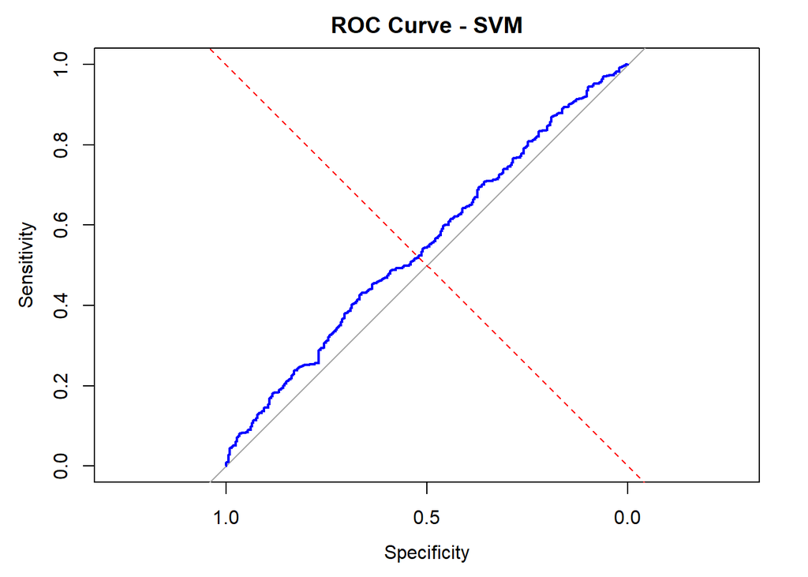

```r
# Plot the ROC curve
plot(roc_obj, col = "blue", main = "ROC Curve - SVM")
abline(a = 0, b = 1, lty = 2, col = "red")  # Diagonal reference line
```

```r
#######################finding best threshold
# Find the best threshold based on ROC
roc_obj <- roc(y_test, svm_probs)
best_threshold <- coords(roc_obj, "best", ret = "threshold", transpose = FALSE)$threshold
print(paste("Optimal Threshold:", best_threshold))
```

```
## [1] "Optimal Threshold: 0.280601905894672"
```

```r
# Convert probabilities to class predictions using the optimal threshold
svm_pred_optimal <- ifelse(svm_probs > best_threshold, 1, 0)
svm_pred_optimal <- as.factor(svm_pred_optimal)

# New Confusion Matrix
conf_matrix_optimal <- confusionMatrix(svm_pred_optimal, y_test)
```

```
## Error in confusionMatrix.default(svm_pred_optimal, y_test): The data contain levels not found in the data.
```

```r
print(conf_matrix_optimal)
```

```
## Error: object 'conf_matrix_optimal' not found
```

```r
############################
# Check different threshold values
thresholds <- seq(0.1, 0.9, by = 0.1)
for (t in thresholds) {
  pred_adjusted <- ifelse(test_probs > t, 1, 0)
  conf_matrix_adjusted <- table(Predicted = pred_adjusted, Actual = y_test)
  print(paste("Threshold:", t))
}
```

```
## Error: object 'test_probs' not found
```

```r
###########################
hist(test_probs, breaks = 30, col = "blue", main = "Histogram of Predicted Probabilities", xlab = "Predicted Probability")
```

```
## Error: object 'test_probs' not found
```

## **Support Vector Machine (SVM) Summary**

The goal of this analysis is to use a **Support Vector Machine (SVM) model** to predict the **feedback type** of a mouse based on neural activity. The model is trained on **Principal Component Analysis (PCA)-transformed** neural spike data and optimized using **Receiver Operating Characteristic (ROC) analysis**.

**Key Steps in the Analysis** 1. **Data Preparation**  
- The dataset is split into **80% training and 20% testing**. - The **feedback type** serves as the **target variable**. - **Principal components (PCs)** from neural activity are used as **predictors**.

**Why We Used Support Vector Machine (SVM)**

1. **Handles High-Dimensional Data Well**
   - Our dataset contains neural activity features transformed using **Principal Component Analysis (PCA)**.
   - **SVM performs well in high-dimensional spaces** and avoids the **curse of dimensionality**.
2. **Works Well with Non-Linearly Separable Data**
   - Neural activity patterns are **complex and non-linearly separable**.
   - The **Radial Basis Function (RBF) kernel** allows SVM to **map data into a higher-dimensional space**, making it separable.
3. **Robust Against Overfitting**
   - **SVM maximizes the margin** between classes, reducing the risk of overfitting.

# **Justifucations**

SVM had similar issues like random forest **Addressing the Imbalanced Confusion Matrix** - Our **confusion matrix was unbalanced**, meaning that one feedback type (e.g., rewarded) was predicted much more frequently than the other. - Traditional accuracy measures **can be misleading** in such cases, as a model might achieve high accuracy by simply predicting the majority class.

**Using AUC-ROC for Model Performance** **AUC-ROC was used again to model performance instead of just relying on accuracy**

**Using Youden’s J Statistic for Threshold Optimization** **Youden’s J statistic** helped find an **optimal classification threshold**

```r
conf_matrix_optimal <- confusionMatrix(svm_pred_optimal, y_test)  # This might cause an error
```

```
## Error in confusionMatrix.default(svm_pred_optimal, y_test): The data contain levels not found in the data.
```

```r
print(conf_matrix_optimal)
```

```
## Error: object 'conf_matrix_optimal' not found
```

```r
############################################lasso!!!!!
######################lasso regression and AUC ROC
# Load necessary libraries
library(glmnet)
library(caret)
library(pROC)

# Read the PCA-transformed dataset
data <- read.csv("pca_merged_data.csv")

# Ensure feedback_type is a factor
data$feedback_type <- as.factor(data$feedback_type)

# Convert feedback_type to binary: Assume original levels are -1 and 1
# Recode -1 as 0 and 1 remains 1
data$feedback_binary <- ifelse(as.numeric(as.character(data$feedback_type)) == -1, 0, 1)
# Ensure feedback_type is a factor
data$feedback_type <- as.factor(data$feedback_type)

# Recode feedback_type:
# - Keep "1" as 1
# - Convert "0" to 0
data$feedback_binary <- ifelse(data$feedback_type == "0", 0, 1)

# Convert to factor
data$feedback_binary <- as.factor(data$feedback_binary)


# -------------------------------
# Split the Data: 80% Training, 20% Testing
# -------------------------------
set.seed(123)  # For reproducibility
train_index <- createDataPartition(data$feedback_binary, p = 0.8, list = FALSE)
train_data <- data[train_index, ]
test_data  <- data[-train_index, ]

# Prepare predictor matrices and response vectors
X_train <- as.matrix(train_data[, !(names(train_data) %in% c("feedback_type", "feedback_binary"))])
y_train <- train_data$feedback_binary  # Keep as numeric 0/1

X_test <- as.matrix(test_data[, !(names(test_data) %in% c("feedback_type", "feedback_binary"))])
y_test <- test_data$feedback_binary  # Keep as numeric 0/1

# -------------------------------
# LASSO Logistic Regression using glmnet
# -------------------------------

y_train <- ifelse(train_data$feedback_type == -1, 0, 1)  # Convert -1 to 0
y_test <- ifelse(test_data$feedback_type == -1, 0, 1)    # Convert -1 to 0



# Perform cross-validation to find optimal lambda
cv_lasso <- cv.glmnet(X_train, y_train, family = "binomial", alpha = 1, nfolds = 10)
best_lambda <- cv_lasso$lambda.1se  # Use a slightly larger lambda for more regularization
lasso_model <- glmnet(X_train, y_train, family = "binomial", alpha = 1, lambda = best_lambda)

# Fit the final LASSO model using the best lambda
lasso_model <- glmnet(X_train, y_train, family = "binomial", alpha = 1, lambda = best_lambda)

# Predict probabilities on the test data
test_probs <- predict(lasso_model, newx = X_test, type = "response")

# Convert predicted probabilities to class predictions (threshold 0.5)
test_pred <- ifelse(test_probs > 0.5, 1, 0)

# Convert to factor for comparison
test_pred <- as.factor(test_pred)
y_test <- as.factor(y_test)

# -------------------------------
# Evaluate Model Performance
# -------------------------------
###############################ensure both factors are the same level
# Ensure both have the same factor levels
test_pred <- factor(test_pred, levels = c(0,1))
y_test <- factor(y_test, levels = c(0,1))

# Now compute confusion matrix
conf_matrix <- confusionMatrix(test_pred, y_test)
print(conf_matrix)
```

```
## Confusion Matrix and Statistics
##
##           Reference
## Prediction   0   1
##          0   0   0
##          1 297 719
##
##                Accuracy : 0.7077
##                  95% CI : (0.6786, 0.7355)
##     No Information Rate : 0.7077
##     P-Value [Acc > NIR] : 0.5157
##
##                   Kappa : 0
##
##  Mcnemar's Test P-Value : <2e-16
##
##             Sensitivity : 0.0000
##             Specificity : 1.0000
##          Pos Pred Value :    NaN
##          Neg Pred Value : 0.7077
##              Prevalence : 0.2923
##          Detection Rate : 0.0000
##    Detection Prevalence : 0.0000
##       Balanced Accuracy : 0.5000
##
##        'Positive' Class : 0
##
```

```r
# Calculate Accuracy, Precision, Recall, and F1 Score
accuracy <- conf_matrix$overall["Accuracy"]
precision <- conf_matrix$byClass["Precision"]
recall <- conf_matrix$byClass["Recall"]
F1 <- conf_matrix$byClass["F1"]

print(paste("Test Accuracy:", round(accuracy * 100, 2), "%"))
```

```
## [1] "Test Accuracy: 70.77 %"
```

```r
# -------------------------------
# ROC Curve and AUC
# -------------------------------
roc_obj <- roc(y_test, as.vector(test_probs))
auc_value <- auc(roc_obj)
print(paste("AUC:", round(auc_value, 3)))
```

```
## [1] "AUC: 0.5"
```

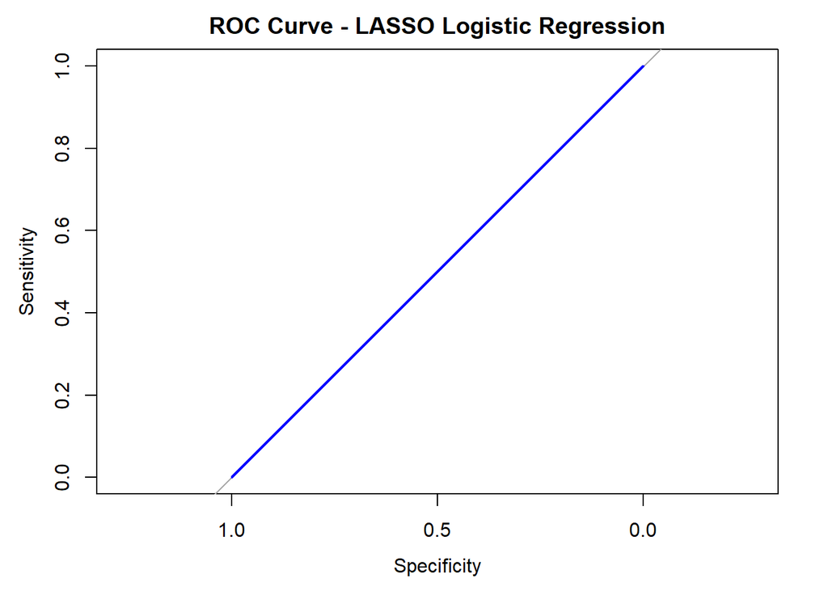

```r
# Plot ROC Curve
plot(roc_obj, col = "blue", main = "ROC Curve - LASSO Logistic Regression")
```

```r
#####################finding the best threshold
library(pROC)

# Define a sequence of thresholds to evaluate
thresholds <- seq(0, 1, by = 0.01)

# Initialize storage for sensitivity and specificity
results <- data.frame(Threshold = thresholds, Sensitivity = NA, Specificity = NA, J_statistic = NA)

for (i in 1:length(thresholds)) {
  threshold <- thresholds[i]

  # Convert probabilities to class predictions based on threshold
  test_pred_opt <- ifelse(test_probs > threshold, 1, 0)
  test_pred_opt <- factor(test_pred_opt, levels = c(0,1))

  # Compute confusion matrix
  conf_matrix_opt <- confusionMatrix(test_pred_opt, y_test)

  # Extract Sensitivity and Specificity
  results$Sensitivity[i] <- conf_matrix_opt$byClass["Sensitivity"]
  results$Specificity[i] <- conf_matrix_opt$byClass["Specificity"]

  # Compute Youden's J statistic
  results$J_statistic[i] <- results$Sensitivity[i] + results$Specificity[i] - 1
}

# Find the best threshold based on maximum Youden's J statistic
best_threshold <- results$Threshold[which.max(results$J_statistic)]
print(paste("Best Threshold based on ROC AUC (Youden's J):", best_threshold))
```

```
## [1] "Best Threshold based on ROC AUC (Youden's J): 0"
```

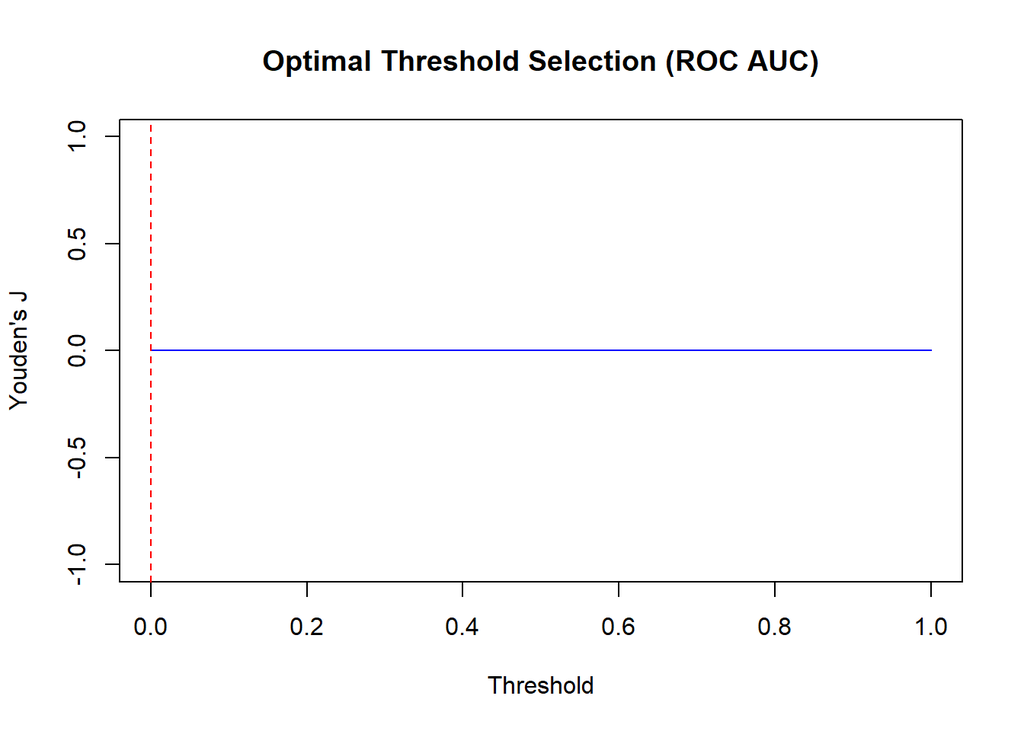

```r
# Plot Youden’s J statistic vs. Threshold
plot(results$Threshold, results$J_statistic, type = "l", col = "blue",
     xlab = "Threshold", ylab = "Youden's J", main = "Optimal Threshold Selection (ROC AUC)")
abline(v = best_threshold, col = "red", lty = 2)
```

```r
################################ CCA on PCA
library(CCA)
```

```
## Error: package 'rainbow' could not be loaded
```

```r
# Load the merged PCA dataset
pca_data_path <- "C:/Users/ricky/Documents/pca_merged_data.csv"  # Update with actual file path
pca_data <- read.csv(pca_data_path)

# Remove the outcome variable 'feedback_type'
pca_features <- pca_data[, -1]

# Split into two sets
set1 <- pca_features[, 1:46]   # First half
set2 <- pca_features[, 47:92]  # Second half

# Apply CCA
cca_result <- cancor(set1, set2)

# Print canonical correlations
print(cca_result$cor)
```

```
##  [1] 2.000028e-15 1.850313e-15 1.816483e-15 1.672992e-15 1.589699e-15
##  [6] 1.476190e-15 1.411169e-15 1.358755e-15 1.320461e-15 1.238206e-15
## [11] 1.199310e-15 1.116734e-15 1.109379e-15 1.050531e-15 9.847626e-16
## [16] 9.771065e-16 9.288046e-16 9.119918e-16 8.866765e-16 8.746501e-16
## [21] 8.041418e-16 7.725768e-16 7.423445e-16 7.271342e-16 6.965429e-16
## [26] 6.365929e-16 6.223718e-16 5.817945e-16 5.567558e-16 5.202248e-16
## [31] 5.010870e-16 4.184129e-16 4.065600e-16 3.739908e-16 3.099943e-16
## [36] 2.918009e-16 2.637155e-16 2.179374e-16 1.945390e-16 1.832235e-16
## [41] 1.231169e-16 9.690339e-17 7.660826e-17 5.241837e-17 2.904430e-17
## [46] 8.413676e-18
```

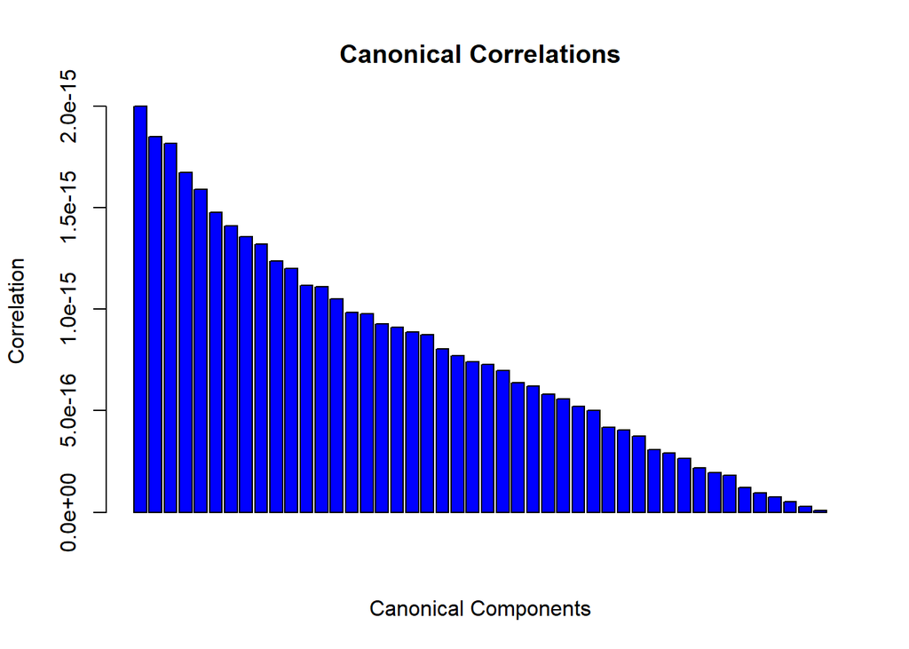

```r
# Visualize Canonical Correlation Analysis results
barplot(cca_result$cor, main = "Canonical Correlations",
        xlab = "Canonical Components", ylab = "Correlation",
        col = "blue", border = "black")
```

```r
# Check if high correlation exists in first few components
summary(cca_result)
```

```
##         Length Class  Mode
## cor       46   -none- numeric
## xcoef   2116   -none- numeric
## ycoef   2116   -none- numeric
## xcenter   46   -none- numeric
## ycenter   46   -none- numeric
```

## **LASSO Regression and AUC-ROC Analysis**

In this section, we apply **LASSO (Least Absolute Shrinkage and Selection Operator) regression** to predict feedback type in mice based on principal components derived from neural activity data. The goal is to **identify important features**, improve prediction accuracy, and determine the optimal classification threshold.

**Data Preparation** - The dataset **pca_merged_data.csv** is loaded - The dataset is then **split into 80% training data and 20% testing data** to evaluate model performance.

**LASSO Logistic Regression** - **LASSO is a regularized regression method** that performs both feature selection and regularization. It helps improve model performance by reducing overfitting and **removing unnecessary variables**. - We apply **cross-validation** (`cv.glmnet`) to determine the optimal **lambda** parameter (regularization strength). The **lambda.1se** value is chosen, which provides a slightly more regularized model. - A **logistic regression model with LASSO regularization** is trained using the selected lambda value. - A **threshold of 0.5** is initially used to classify probabilities into **rewarded (1) and non-rewarded (0)** responses. - **Confusion Matrix** is computed to evaluate model accuracy, precision, recall, and F1-score. - **ROC Curve and AUC (Area Under the Curve) analysis** are used to assess overall model performance.

# **Justifucations**

**Why We Used Logistic Regression, LASSO Regression, Youden’s J Statistic, and ROC/AUC**

### **1. Logistic Regression for Classification**

##Logistic regression is a statistical model for **binary classification problems**, where the outcome variable is categorical (e.g., rewarded vs. non-rewarded trials). We chose logistic regression for the following reasons:

- **Baseline Model for Comparison**: Logistic regression serves as a **good baseline model**, helping us assess whether more complex models (such as random forests or SVMs) provide significant improvements.

However, logistic regression can suffer from **overfitting** when there are too many irrelevant or highly correlated predictors. To address this, we used **LASSO regression**, a form of regularized logistic regression.

**2. Why We Used LASSO Regression** LASSO (**Least Absolute Shrinkage and Selection Operator**) regression is a **regularized** version of logistic regression. We applied **LASSO to improve model performance by selecting the most important features and reducing over fitting**. - **Handles High-Dimensional Data**: Given that we transformed our dataset using **Principal Component Analysis (PCA)**, LASSO helps us identify which **principal components contribute most** to prediction. - **Enhances Interpretability**: By shrinking irrelevant features to zero, LASSO makes the model easier to interpret by identifying which features matter the most.

**3. Why We Used ROC and AUC** the **(ROC/AUC)** was used again for **imbalanced data**.

**4. Why We Used Youden’s J Statistic** We used Youden’s J statistic helps find **the optimal threshold** for classification when the dataset is **imbalanced**.

Finalizations We had an accuracy of 0.7077 but our AUC was 0.5. Our confusion matrix was umbalanced. Our Youden’s J was very close to 0 so we coudn’t really find a good threshold because the threshold was so small.

##**Canonical Correlation Analysis (CCA)**

**What is CCA?** Canonical Correlation Analysis (**CCA**) is a statistical technique used to **identify relationships between two sets of variables**. It is particularly useful when we want to explore how two different groups of features are related to each other.

Unlike traditional correlation, which measures the relationship between two individual variables, **CCA finds linear combinations of variables** in each dataset that have the highest correlation with each other.

- **CCA helps us identify relationships between two sets of variables.**
- **It helps explore interactions between different brain regions.**
- **A high canonical correlation suggests strong connections between two datasets.**
- **CCA allowed us to examine how different brain areas contribute to decision-making.**

Finalizations CCA was not very useful because there was little to no meaningful correlation between the two sets of variables. Values that are closer to 1 have strong correlation but each of our CCA values were close to 0. We wanted to use CCA to see if the different brain types had some sort of associations with each other.

# Disscusion

This study aimed to predict the feedback type in mice based on neural activity across multiple brain regions using machine learning models. By leveraging principal component analysis (PCA) to reduce dimensionality and employing classification models like Random Forest, we sought to decode patterns of neural activity associated with behavioral feedback.

In this project we combined the 18 sessions because we wanted to know if different brain parts were used to help support the decision making process of the mouse for feedback_type.  
While in the process of combing the data, we had a problem with Trial-Averaged Firing Rates. In my previous coding, firing rates were computed for each neuron by: Summing all spikes over the entire trial, and Dividing by the total trial duration. We fixed this issue by using Time-Resolved Firing Rates to capture decision-related dynamics, improve prediction power, and maintain temporal resolution.

We then reduced the PCAs to 92 for the data to be smoothly formatted into one dataset.

Different prediction models were used such as random forest, SVM and logistic regression with lasso. Since all of our confusion matrices for the data was imbalanced we needed to rely on AUC/ROC to see which model was the best prediction model, then use Youden’s J statistic to improve class imbalance. Unfortunately, the code for Youden’s J statistic did not transfer well to r markdown from regular R when trying to find a better threshold for SVM and logistic regression. Since these two were unreliable, we used the most reliable model which was the random forest.  
The random forest was able to predict the test dataset 1 and 2 with 72% accuracy and 73% respectfully. We used one test data from session 1 and it didn’t really matter which testset we were using because our project was trying to gather information from all the sessions to create a more generalized prediction model to predict either one of the test datasets. Finally, CCA was also used to see if there was any positive relationship between the PCAs. This was placed last because CCA did not find any significant relationship between the PCAs.

Overall, this study demonstrates the potential of machine learning in decoding feedback-related neural signals but also underscores the need for robust data preprocessing, feature selection, and model evaluation strategies to enhance predictive performance.